# Limiting dilution analysis (lda) with R

Toshiaki Ara

2018-11-18

# 1 データおよび解析

骨髄細胞の中に造血幹細胞が含まれているが、細胞何個あたりに1個の造血幹細胞が含まれているかを調べる時に limiting dilution法が使用される。

ここではRを使用してlimiting dilution法による造血幹細胞の頻度を求める方法を示す。

```r
dat <- data.frame(
    dose = c(500, 1000, 2000, 3000), # 移植する細胞数
    dead = c(6, 4, 2, 1),            # 死亡した個体（造血幹細胞が0個だった場合）
    total = c(10, 10, 10, 10)        # 移植に使用した各群の個体数
)
```

## 1.1 従来の方法

レシピエント動物に対して造血幹細胞が何個移植されるのかはPoisson分布に従う。 したがって、Poisson回帰によって造血幹細胞の頻度を求めることができる。

```r
# Poisson回帰
res <- glm(dead ~ dose + offset(log(total)) - 1, ## log(total) はオフセット項
           family = poisson, data = dat)
Coef <- coefficients(res)
(lambda <- -1 / Coef)
```

```
    dose
1208.107
```

すなわち、1208 個の細胞に1個の造血幹細胞が含まれていたという結果になる。

```r
# 95%信頼区間を求める関数
lmres <- function(glm_res, conf.level = 0.95) {
    lambda <- coefficients(glm_res)
    CI <- confint(glm_res, level = conf.level)
    res <- -1 / c(CI[2], lambda, CI[1])
    names(res) <- c("Lower", "Estimate", "Upper")
    return(res)
}
```

```r
res_CI <- lmres(res)
res_CI
```

```
    Lower  Estimate     Upper
2188.2738 1208.1074  756.6155
```

すなわち、95%信頼区間の下限が2188 個に1個、上限が 757 個に1個の造血幹細胞を含むという結果になる。

## 1.2 elda法

Extreme Limiting Dilution Analysis

```r
library(statmod)
res_elda <- with(dat, elda(total - dead, dose, total, test.unit.slope = FALSE))
res_elda$CI
```

```
           Lower Estimate    Upper
Group 1 1800.026 1170.908 761.6699
```

すなわち1171 個の細胞に1個の造血幹細胞が含まれていたという結果になる。 また、95%信頼区間の下限が1800 個に1個、上限が 762 個に1個の造血幹細胞を含むという結果になる。

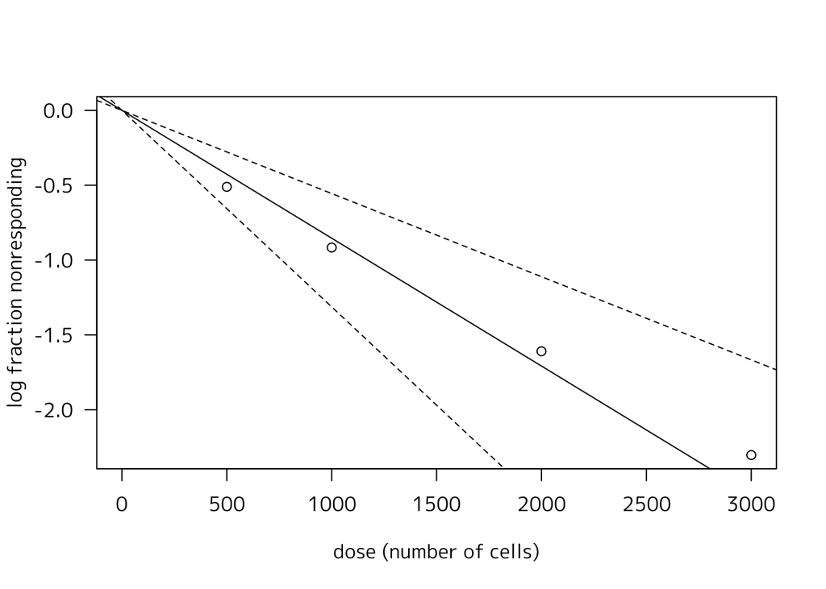

```r
plot(res_elda, las = 1)
```

`test.unit.slope = TRUE`の時はあてはめの結果を出力する。

```r
res_elda <- with(dat, elda(total - dead, dose, total, test.unit.slope = TRUE))
res_elda
```

```
Confidence intervals for frequency:

           Lower Estimate    Upper
Group 1 1800.026 1170.908 761.6699

Goodness of fit (test log-Dose slope equals 1):
                      Estimate Std. Error  z value Pr(>|z|)
Wald test                0.836    0.33325 -0.49215   0.6226
LR test                     NA         NA -0.48518   0.6275
Score test: log(Dose)       NA         NA -0.49472   0.6208
Score test: Dose            NA         NA -0.47594   0.6341
```